# Homework 8

## Context

You are the data person on your team, because you know `R` and are excellent with data 😎. Your team has been working on a project and is now getting ready to analyze and write up findings. You have student data, including a random ID, student names, scores, dates, and some student demographic information (note that *frl* represents students who received free/reduced priced lunch). (All of the data here are randomly generated and thus not real.) Your team wants you to prepare the data for analysis and reporting. *Note*. There are not necessarily correct answers to some the questions I am asking below.

Produce a Quarto document that combines code and prose to complete this assignment.

### 1. Start a new RStudio Project

#### 1.1. Be sure to add a folder for “data” and “scripts”.

### 2. Data

#### 2.1. Download the following data from the course website.

- `hw8_ids.xlsx`
- `hw8_scores.csv`
- `year1_score.csv`
- `year1_demo.xlsx`
- `year2_score.csv`
- `year2_demo.xlsx`

#### 2.2. Place the files in the “data” folder in your project.

#### 2.3. Read in the data.

```r
hw8_ids <- read_csv(here::here("data", "hw8_ids.csv"))
hw8_scores <- read_csv(here::here("data", "hw8_scores.csv"))
year1_score <- read_csv(here::here("data", "year1_score.csv"))
year2_score <- read_csv(here::here("data", "year2_score.csv"))
year1_demo <- import(here::here("data", "year1_demo.xlsx")) |>
  as_tibble()
year2_demo <- import(here::here("data", "year2_demo.xlsx")) |>
  as_tibble()
```

### 3. Join

#### 3.1.

Join the `hw8_ids` data and the `hw8_scores` data by student ID. Name the joined data `student_scores`.

What issue(s), if any, did you encounter when you were joining? What did you do decide to do and why? What options did you consider? *Note*. *I am less interested here in your code than in your response to my questions.*

**There are two issues. 1) `hw8_ids` has 3 rows for id == 51, where Naomi Baker appears twice (duplicated) and Elliott Rundel once. So the same ID is associated with two different names. 2) In `hw8_scores`, id_student == 21 has two different scores. Also, the ID column had a different name in each data file.**

**There is no right answer here. But my choice was to remove id == 51 from `hw8_ids` entirely, because it was not acceptable to have different names with the same ID because we do not know for sure which score they should get from `hw8_scores.`**

**I kept both scores for id_student == 21 from `hw8_scores`, because I did not want to delete both, and thought it was unacceptable to choose just one, or average the two.**

```r
student_scores <- hw8_ids |>
  filter(id != 51) |>
  left_join(hw8_scores, join_by(id == id_student))
```

#### 3.2.

Join the `hw8_ids` data and the `year1_score` data by student ID. Name the joined data `year1`. **This joined data must have one row per student.** You are allowed to use code to remove rows if you must.

Detail the `join` for your team. What issue(s), if any, did you encounter when you were joining? What did you do decide to do and why? What options did you consider? Use inline code to report the initial and the final student *n*, and how many students (%) were excluded.

**There are a few issues with the data. Perhaps the biggest issue is that `hw8_ids` has 3 rows for id == 51, where Naomi Baker appears twice (duplicated) and Elliott Rundel once. So the same ID is associated with two different names. I chose to remove id == 51 because it is not possible to know which is the correct name for the ID. Also, the ID column had a different name in each data file.**

**For `year1_score`, id_student == 21 has two different scores. I chose to select the score associated with the last date. I also removed all rows with missing id_student.**

```r
year1 <- hw8_ids |>
  filter(id != 51) |>
  left_join(
    year1_score |>
      filter(!is.na(id_student)) |>
      arrange(id_student, desc(date)) |>
      group_by(id_student) |>
      mutate(n = row_number()) |>
      filter(n == 1) |>
      select(-n),
    join_by(id == id_student)
  )
```

#### 3.4.

Join the newly created `year1` data and the `year1_demo` data. Name the joined data `year1`. What issue(s), if any, did you encounter when you were joining?

**No issues joining.**

```r
year1 <- year1 |>
  left_join(year1_demo)
```

#### 3.4.

Join the newly created `year1` data and the `year2_score` and `year2_demo` data. Name the joined data `year12`. What issue(s), if any, did you encounter when you were joining?

**I had to rename the FRL column in `year2_demo` to match the lowercase of the same column in the `year1_demo` file.**

**In addition, I renamed the variables with a suffix to indicate the year the columns were from.**

```r
year12 <- year1 |>
  left_join(
    year2_score |>
      filter(!is.na(id_student)),
    suffix = c("_year1", "_year2"),
    join_by(id == id_student)
  ) |>
  left_join(
    year2_demo |>
      rename(frl = FRL),
    suffix = c("_year1", "_year2"),
    join_by(id)
  )
```

### 3. Report

Create a figure to show the relation between scores from Year 1 and Year 2. Describe the relation.

Report the mean and standard deviation for scores from Year 1 and Year 2 using inline code. Describe the change.

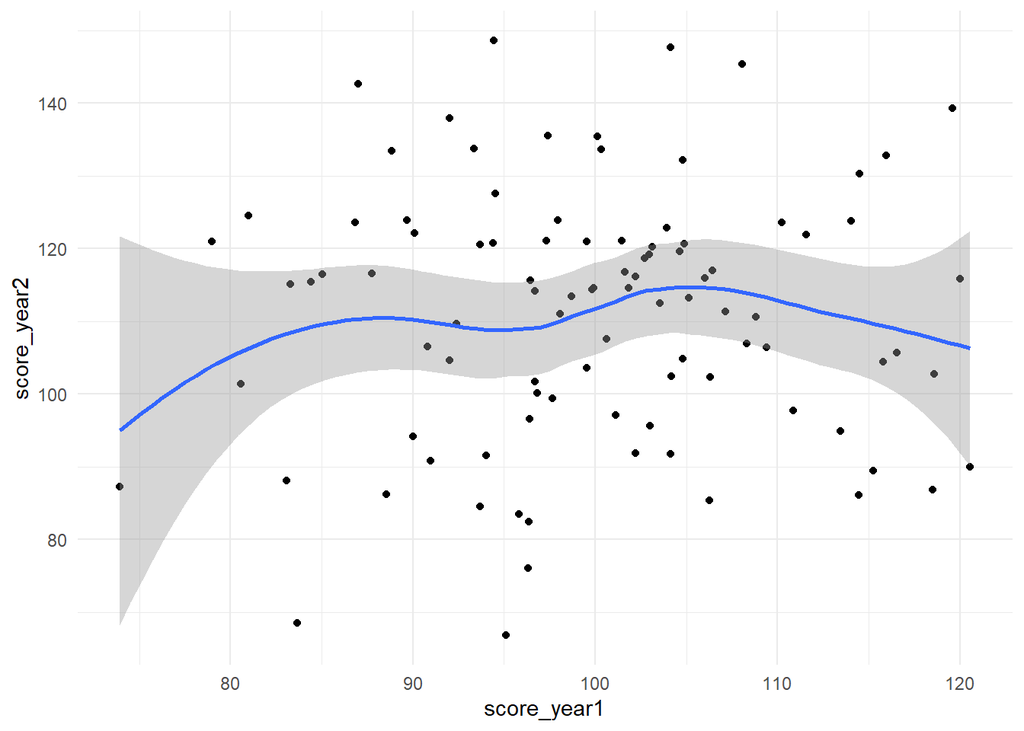

```r
year12 |>
  mutate(gain = score_year2 - score_year1) |>
  ggplot(aes(score_year1, score_year2)) +
  geom_point() +
  geom_smooth() +
  theme_minimal()
```

**There appears to be no discernible correlation between Year 1 and Year 2 scores.**

**The mean score for Year 1 was 100 (*SD* = 10.3), and for Year 2 was 111 (*SD* = 17.5). The effect size change from Year 1 to Year 2 was 1.0641863, indicating a difference of about 1 standard deviation from Year 1 to Year 2 - quite large and meaningful!**